# Minería y Análisis de Datos: Proyecto Final

Comprensión de los Datos

Alejandra Lelo de Larrea Ibarra 000124433

Dante Ruiz Martínez 183340

José Carlos Escobar Gutiérrez 175895

```r
source('01_Libraries.R')
```

```r
source('02_Utils.R')
```

# 1 Recolección de los datos iniciales

La recolección de los datos iniciales se realiza directamente desde la terminal. Para ello es necesario realizar los siguientes pasos:

1. Asegurarse de que se tiene una versión de python 3 o superior. De no ser así, actualizar python (por ejemplo, se pueden seguir las instrucciones en https://docs.python-guide.org/starting/install3/osx/).
2. Acceder a su cuenta de Kaggle. De no tener una, es necesario registrarse en https://www.kaggle.com/.
3. Una vez que se accedió a la cuenta, ingresar a la sección **“My Account”**

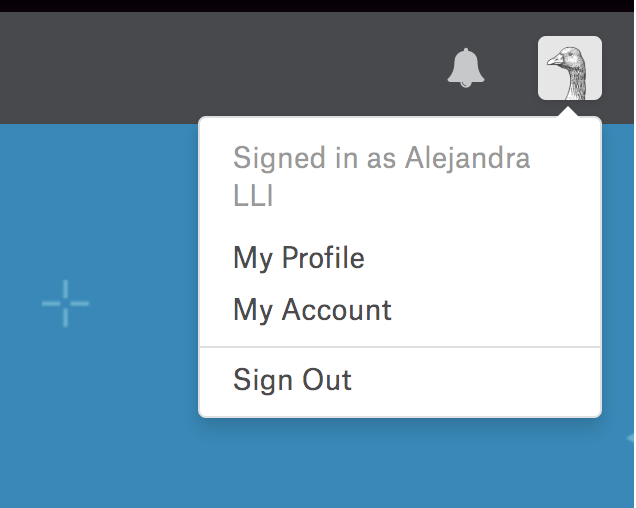

4. Obtener un token en formato .json en la sección **API** seleccionando el botón **“Create New API Token”**. Guardar este token en la carpeta de **“Downloads”** del directorio raíz.

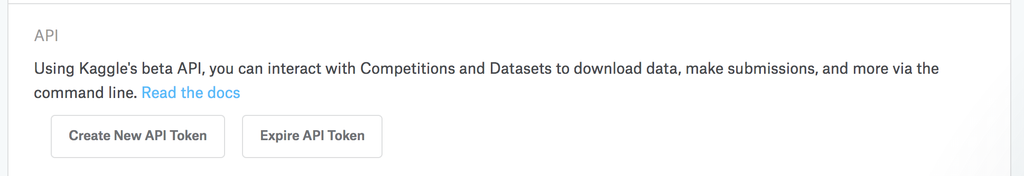

5. Correr el archivo **DescargaDatos.sh** en la terminal. Este archivo:
   1. Installa la API de Kaggle.
   2. Crea el directorio **.kaggle** en la raíz.
   3. Transfiere el token a la carpeta del paso anterior.
   4. Crea la carpeta **Proyecto_Final** en dentro del directorio **Documents**.
   5. Crea las carpetas **Datos**, **Datos_trad** y **Datos_clean** dentro del directorio del proyecto final.
   6. Descarga los datos de la competencia *Predict Future Sales* en la carpeta **Datos**.
   7. Descomprime los archivos con extensión **.gz**

# 2 Descripción de los datos

# 3 Exploración de los datos

Para poder realizar una exploración de los datos, primero es necesario convertir los campos en ruso a un idioma que podamos entender. Elegimos la traducción al inglés para tratar de ganar la mayor precisión posible. Cabe destacar que esto es parte del proceso de limpieza de datos; sin embargo, para tener la capacidad de interpretar el análisis exploratorio, consideramos importante realizar la traducción en este paso.

## 3.1 Traducción del ruso al inglés

Para la traducción de los catálogos del ruso al inglés se utilizó la librería translateR de R y la API de Google Translate. Los datos traducidos se almacenaron en el objeto **transdata.RData**. Dentro de este objeto se encuentran los siguientes data_frames:

1. **item_category_ru**: corresponde al archivo **item_category.csv** original. Es decir, con el nombre de las categorías sólo en ruso.
2. **item_category_en**: corresponde al archivo **item_category.csv** con los nombres de las categorías tanto en ruso como en inglés.
3. **item_category**: corresponde al archivo **item_category.csv** con los nombres de las categorías únicamente en inglés.
4. **items_ru**: corresponde al archivo **items.csv** original. Es decir, con el nombre de los artículos sólo en ruso.
5. **items_en**: corresponde al archivo **items.csv** con los nombres de los artículos tanto en ruso como en inglés.
6. **items**: corresponde al archivo **items.csv** con los nombres de los artículos únicamente en inglés.
7. **shops_ru**: corresponde al archivo **shops.csv** original. Es decir, con el nombre de las tiendas sólo en ruso.
8. **shops_en**: corresponde al archivo **shops.csv** con los nombres de las tiendas tanto en ruso como en inglés.
9. **shops**: corresponde al archivo **shops.csv** con los nombres de las tiendas únicamente en inglés.

El proceso para la traducción de los catálogos se puede encontrar en el archivo **Traduccion.Rmd**. Cabe destacar que para poder utilizar la API de Google Translate es necesario generar una llave y esto puede ocasionar costos, por lo que se decide no incluir la llave en el archivo. Si desea realizar la traducción para nuevos datos, es necesario reemplazar el caracter *“Please_use_your_own_API_key”* del archivo **Traduccion.Rmd** por una llave válida de Google Translate.

Para generar una llave de la API de Google Translate, se requieren los siguientes pasos:

1. Ingresar a la liga https://console.cloud.google.com/
2. Generar un proyecto de la barra de arriba.

[figure not shown]

$\Rightarrow$

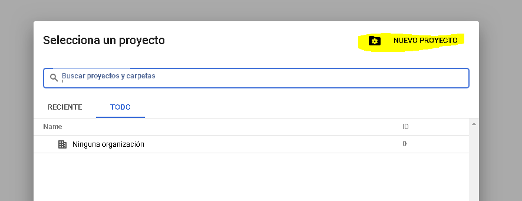

$\Rightarrow$

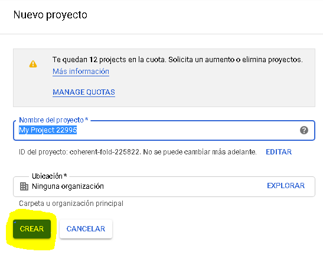

3. Posteriormente, ir al menú “hamburguesa” en la parte superior izquierda y seleccionar “Servicios & API”.

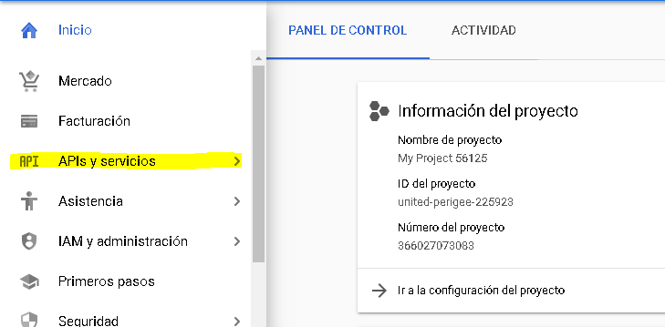

4. Del dashboard de la plataforma, hacer la búsqueda de “Google Translate API” y habilitarla.
5. Del menú de la izquierda seleccionar “credenciales” > Generar credenciales > API Key.
6. Copiar la llave del API generada para usar en el código en el archivo **Traducción.Rmd**.

## 3.2 Cargar catálogos y datos entrenamiento

```r
# Cargamos catálogos traducidos
load('datos_trad/transdata.RData')

# Eliminamos los catalogos en ruso, así como los de ruso e inglés para que no ocupen memoria.
rm(item_category_en,item_category_ru,items_en,items_ru,shops_en,shops_ru)

# Cargamos los datos de entrenamiento. Estos no contienen campos en ruso.
train<-read_csv("datos/sales_train.csv")
```

### 3.2.1 Catálogo de artículos y categorías

El catálogo de artículos y de categorías se pueden juntar. Se hace un left join de éstos y se almacena en el data_frame **datos_items**.

```r
# Unimos items y item_category con la variable item_category_id.
datos_items<-left_join(items,item_category,by="item_category_id")%>%
  select(item_id, item_name, item_category_id, item_category_name)


# Guardamos como objeto Rds
saveRDS(datos_items,"Datos_trad/datos_items.rds")
```

Echamos un vistazo a los datos. Los identificadores se leen como variables enteras y los nombres de los artículos y las categorías como caracteres. Por lo tanto, no hay que reasignar tipos de variables por el momento.

```r
glimpse(datos_items)
```

```
## Observations: 22,170
## Variables: 4
## $ item_id            <int> 0, 1, 2, 3, 4, 5, 6, 7, 8, 9, 10, 11, 12, 1...
## $ item_name          <chr> "! IN POWER OF OVERVIEW (PLASTIC) D", "! AB...
## $ item_category_id   <int> 40, 76, 40, 40, 40, 40, 40, 40, 40, 40, 40,...
## $ item_category_name <chr> "Cinema - DVD", "Programs - Home and Office...
```

```r
# No. de artículos distintos de acuerdo con el item_id
nrow(datos_items %>% select(item_id) %>% unique())
```

```
## [1] 22170
```

```r
# No. de artículos distintos de acuerdo con el item_name
nrow(datos_items %>% select(item_name) %>% unique())
```

```
## [1] 22143
```

```r
# No de nombres de artículos repetidos
length(datos_items$item_name[which(duplicated(datos_items%>%select(item_name)))])
```

```
## [1] 27
```

Utilizando el identificador de artículo se verifica que se cuenta con 22,170 artículos distintos. Sin embargo, cuando se utiliza el nombre del artículo se tienen 27 repetidos, esto puede deberse a imprecisiones en la traducción. Durante el proceso de estimación será indispensable utilizar sólo el identificador del artículo y no el nombre.

```r
# No. de cateogrías distintas.
nrow(datos_items %>% select(item_category_name) %>% unique())
```

```
## [1] 84
```

Obtenemos el número de artículos que pertenecen a cada categoría y los ordenamos de mayor a menor.

```r
# Obtenemos el conteo de articulos por categoría
productos_por_categoria <- datos_items %>%
  group_by(item_category_id) %>%
  summarise(conteo = n())%>%
  left_join(item_category,key='item_category_name') %>%
  select(item_category_id,item_category_name,conteo)%>%
  arrange(desc(conteo))

# Imprimimos una tabla.
productos_por_categoria_table<-productos_por_categoria
names(productos_por_categoria_table)<-c('Cat_Id','Categoria','No. Articulos')

datatable(productos_por_categoria_table)
```

|  | Cat_Id | Categoria | No. Articulos |
| --- | --- | --- | --- |
| 1 | 40 | Cinema - DVD | 5035 |
| 2 | 55 | Music - Local Production CD | 2365 |
| 3 | 37 | Cinema - Blu-ray | 1780 |
| 4 | 31 | PC Games - Digital | 1125 |
| 5 | 58 | Music - Vinyl | 790 |
| 6 | 30 | PC Games - Standard Editions | 756 |
| 7 | 72 | Gifts - Figures | 666 |
| 8 | 19 | Games - PS3 | 628 |
| 9 | 61 | Gifts - Attributes | 598 |
| 10 | 23 | Games - XBOX 360 | 501 |

[output cut: 74 more lines]

Se tiene que las categorías con mayor número de artículos son Cinema-DVD, Music- Local Production CD, Cinema-Blu-ray, PC Games-Digital y Music-Vinyl; es decir, categorías relacionadas con la división de entretenimiento de la empresa.

Las categorías con menor número de artículos son Service, Books-Cognitive Literature, Game Consoles - PS2, Books- Postcards y Accesories -PS2; es decir, aquellos artículos relacionados con la división de educación y con el PS2.

Las siguientes gráficas muestran el top-10 y bottom-10 de categorías por el número de artículos que contienen.

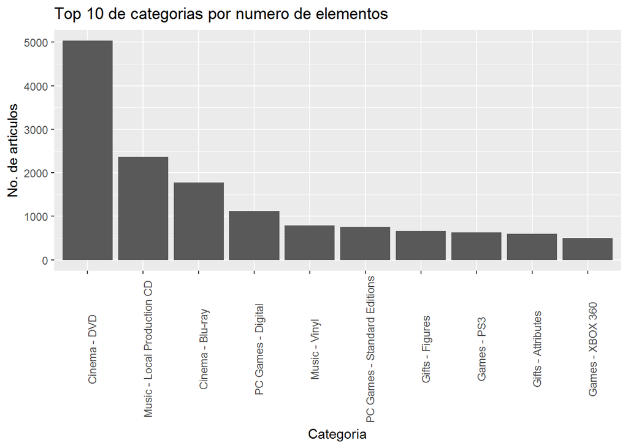

```r
top10<-productos_por_categoria%>%
  top_n(10)

ggplot(top10,aes(x = factor(item_category_id,top10$item_category_id[1:10]), y = conteo)) +
    geom_bar(stat = "identity")+
  theme(axis.text.x=element_text(angle=90))+
  ggtitle('Top 10 de categorias por numero de elementos')+
  xlab('Categoria')+
  ylab('No. de articulos')+
  scale_x_discrete(labels=top10$item_category_name)
```

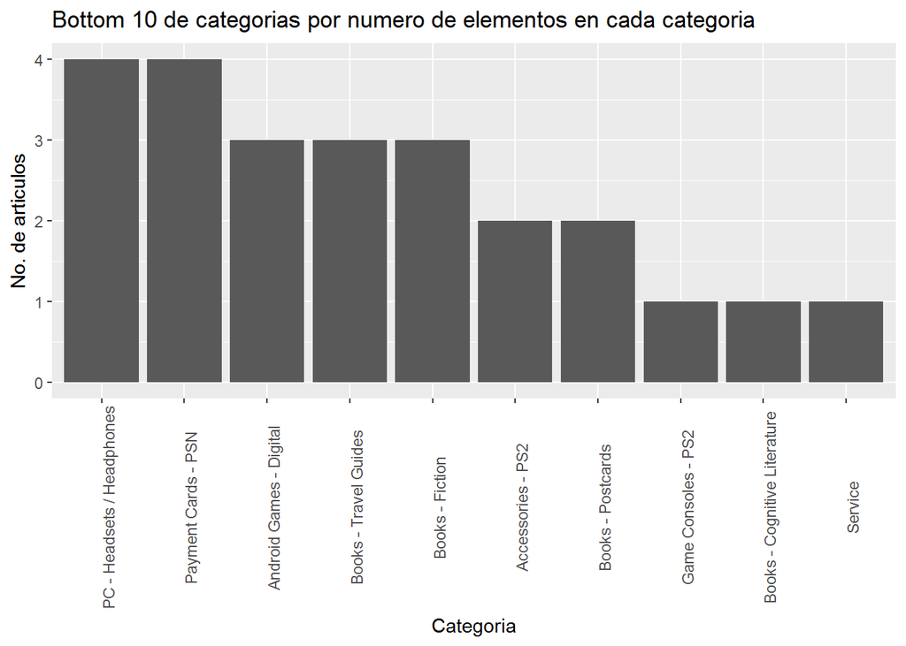

```r
bottom10<-productos_por_categoria%>%
  top_n(-10)

ggplot(bottom10,aes(x = factor(item_category_id,bottom10$item_category_id[1:10]), y = conteo))+
    geom_bar(stat = "identity")+
  theme(axis.text.x=element_text(angle=90))+
  ggtitle('Bottom 10 de categorias por numero de elementos en cada categoria')+
  xlab('Categoria')+
  ylab('No. de articulos')+
  scale_x_discrete(labels=bottom10$item_category_name)
```

### 3.2.2 Catalogo de tiendas

Echamos un vistazo a los datos.

```r
glimpse(shops)
```

```
## Observations: 60
## Variables: 2
## $ shop_name <chr> "! Yakutsk Ordzhonikidze, 56 fran", "! Yakutsk Shopp...
## $ shop_id   <int> 0, 1, 2, 3, 4, 5, 6, 7, 8, 9, 10, 11, 12, 13, 14, 15...
```

```r
# Guardamos como objeto Rds
saveRDS(shops,"Datos_trad/shops.rds")
```

```r
nrow(shops %>% select(shop_name) %>% unique())
```

```
## [1] 60
```

### 3.2.3 Datos de entrenamiento

Echamos un vistazo a los datos de entrenamiento.

```r
glimpse(train)
```

```
## Observations: 2,935,849
## Variables: 6
## $ date           <chr> "02.01.2013", "03.01.2013", "05.01.2013", "06.0...
## $ date_block_num <int> 0, 0, 0, 0, 0, 0, 0, 0, 0, 0, 0, 0, 0, 0, 0, 0,...
## $ shop_id        <int> 59, 25, 25, 25, 25, 25, 25, 25, 25, 25, 25, 25,...
## $ item_id        <int> 22154, 2552, 2552, 2554, 2555, 2564, 2565, 2572...
## $ item_price     <dbl> 999.00, 899.00, 899.00, 1709.05, 1099.00, 349.0...
## $ item_cnt_day   <dbl> 1, 1, -1, 1, 1, 1, 1, 1, 1, 3, 2, 1, 1, 2, 1, 2...
```

Vemos que algunas variables no están siendo reconocidas con el tipo correcto, también faltan los nombres de los artículos, de las tiendas y de las categorías.

Primero hacemos el left join de los datos de entrenamiento con el catálogo de artículos y con el de tiendas.

```r
# Se unen las distintas tablas
datos_train<-left_join(train,datos_items,by='item_id')%>%
  left_join(shops,by='shop_id')

# Se vuelve a leer el tipo de cada dato.
readr::type_convert(datos_train)
```

```
## # A tibble: 2,935,849 x 10
##    date       date_~ shop_~ item_~ item~ item~ item_n~ item~ item_~ shop_~
##    <chr>       <int>  <int>  <int> <dbl> <dbl> <chr>   <int> <chr>  <chr>
##  1 02.01.2013      0     59  22154   999  1.00 Scene ~    37 Cinem~ Yaros~
##  2 03.01.2013      0     25   2552   899  1.00 DEEP P~    58 Music~ Mosco~
##  3 05.01.2013      0     25   2552   899 -1.00 DEEP P~    58 Music~ Mosco~
##  4 06.01.2013      0     25   2554  1709  1.00 DEEP P~    58 Music~ Mosco~
##  5 15.01.2013      0     25   2555  1099  1.00 DEEP P~    56 Music~ Mosco~
##  6 10.01.2013      0     25   2564   349  1.00 DEEP P~    59 Music~ Mosco~
##  7 02.01.2013      0     25   2565   549  1.00 DEEP P~    56 Music~ Mosco~
##  8 04.01.2013      0     25   2572   239  1.00 DEFTON~    55 Music~ Mosco~
##  9 11.01.2013      0     25   2572   299  1.00 DEFTON~    55 Music~ Mosco~
## 10 03.01.2013      0     25   2573   299  3.00 DEL RE~    55 Music~ Mosco~
## # ... with 2,935,839 more rows
```

Veamos cuantas duplas del tipo (tienda,artículo) distintas tenemos en el set de entrenamiento.

```r
nrow(unique(datos_train[,c('shop_id','item_id')]))
```

```
## [1] 424124
```

Se tienen 424,124 duplas en el set de entrenamiento de las $22,170*60=1,330,200$ posibles. Esto quiere decir que existen varios artículos que no han sido vendidos en varias de las tiendas.

# 4 Almacenamiento de los datos

Almacenamos la base de datos en el archivo **Datos_trad/train_trad.rds**.

```r
# Guardamos como objeto Rds
saveRDS(datos_train,"Datos_trad/train_trad.rds")
```

# 5 Análisis Exploratorio de Datos

En esta sección se presenta un análisis exploratorio de los datos disponibles. Las distribuciones para varias de las variables están muy concentradas cerca de un sólo valor o contienen gran cantidad de datos atípicos por lo que los boxplot no son una buena representación gráfica. Es por ello, que la mayoría de las variables se analizan con histogramas o con series de tiempo.

## 5.1 Análisis Univariado

Las variables *shop_name*, *item_name* y *item_category_name* son iguales a los identificadores únicos *shop_id*, *item_id* y *item_category_id*, por lo que no se realiza el análisis univariado de estas variables. En esta sección se analiza el número de registros que tiene cada identificador, así como las distribuciones del precio de los artículos y de las ventas diarias.

### 5.1.1 Date

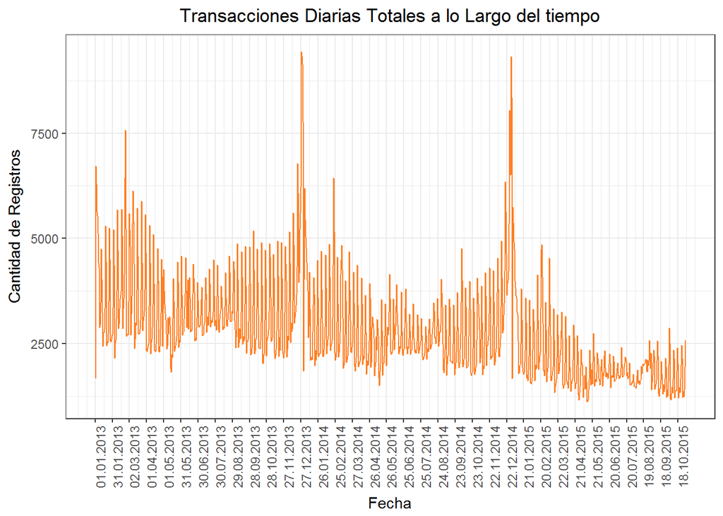

```r
aux_plot<-datos_train%>%
  mutate(day=as.numeric(substring(date,1,2)),
         month=as.numeric(substring(date,4,5)),
         year=as.numeric(substring(date,7)))%>%
  group_by(date)%>%
  summarize(count_items=n(),
            day=unique(day),
            month=unique(month),
            year=unique(year))%>%
  arrange(year,month,day)%>%
  mutate(id=1:length(unique(datos_train$date)))



ggplot(aux_plot,aes(x = id, y = count_items))+theme_bw()+
  geom_line(color='chocolate1')+
  theme(axis.text.x=element_text(angle=90),
        plot.title = element_text(hjust=0.5))+
  ggtitle('Transacciones Diarias Totales a lo Largo del tiempo')+
  xlab('Fecha')+
  ylab('Cantidad de Registros')+
  scale_x_continuous(breaks=aux_plot$id[seq(1,1034,30)],labels=aux_plot$date[seq(1,1034,30)])+
  theme(axis.text.x=element_text(angle=90))
```

### 5.1.2 Date_block_num

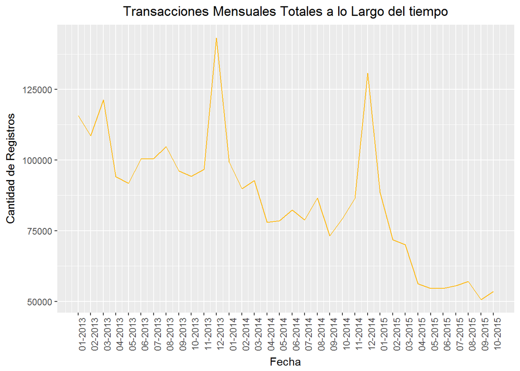

```r
aux_plot<-datos_train%>%
  group_by(date_block_num)%>%
  summarize(count_items=n(),
            mes=unique(substring(date,4,5)),
            anio=unique(substring(date,7)))%>%
  arrange(date_block_num)%>%
  mutate(Fecha=paste(mes,anio,sep='-'))


ggplot(aux_plot,aes(x = date_block_num, y = count_items))+
  geom_line(color='darkgoldenrod1')+
  theme(axis.text.x=element_text(angle=90),
        plot.title = element_text(hjust=0.5))+
  ggtitle('Transacciones Mensuales Totales a lo Largo del tiempo')+
  xlab('Fecha')+
  ylab('Cantidad de Registros')+
  scale_x_continuous(breaks=aux_plot$date_block_num,labels=aux_plot$Fecha)
```

En cuanto a las transacciones mensuales de la empresa, se puede observar una tendencia decreciente a lo largo del periodo muestral. Las ventas se incrementan sustancialmente en el mes de diciembre y tienen un pico mucho más pequeño a la mitad del año.

### 5.1.3 Tiendas

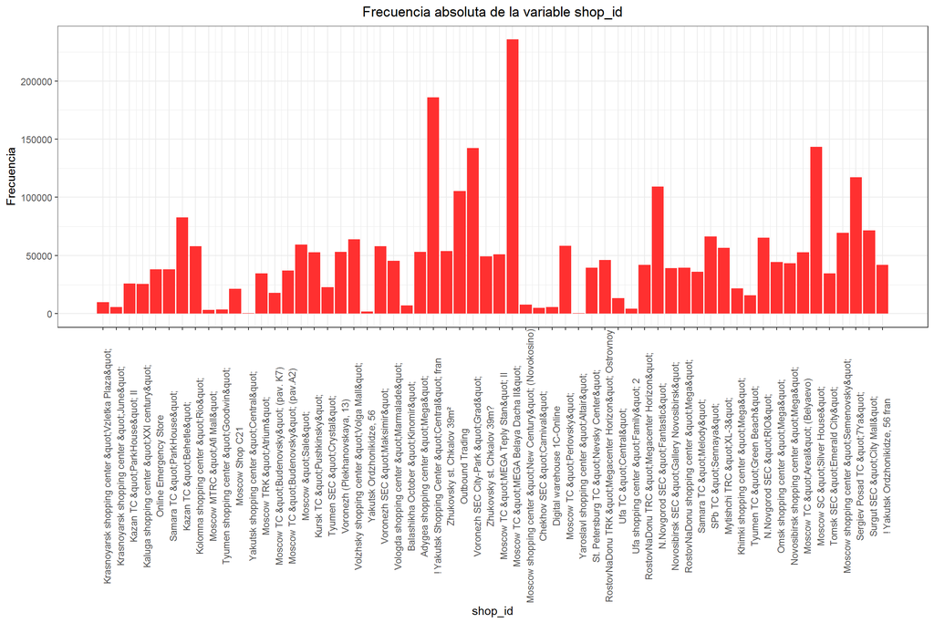

```r
GraficaFrecAbs(datos_train,"shop_id",color='firebrick1',at=unique(datos_train$shop_id),labs=shops$shop_name,angulo=90,bin.width=1)
```

Vemos que las tiendas con mayor número de registros en la base; es decir, con mayor número de transacciones, son Moscow TC MEGA Teply Stan, Yakutsk Shopping Center, Moscow SC Silver House, Voronezh SEC City Park Grad y Sergeiv Posad TC. La tienda con menor número de transaccones es Yaroslavl Shopping Center.

### 5.1.4 Artículos

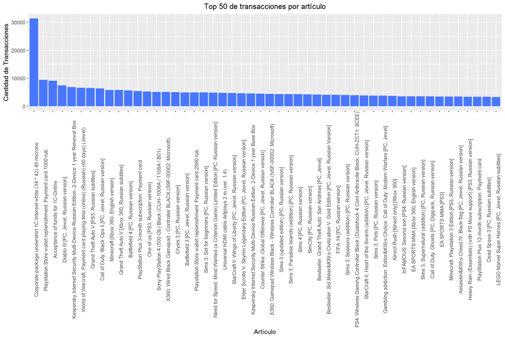

```r
aux_plot<-datos_train%>%
  group_by(item_id)%>%
  summarize(transactions=n(),
            item_name=unique(item_name))%>%
  arrange(desc(transactions))

aux_plot<-aux_plot[1:50,]%>%
  mutate(item_id=factor(item_id,aux_plot$item_id))

ggplot(aux_plot,aes(x = item_id, y = transactions))+
  geom_bar(stat = "identity",fill='royalblue1')+
  theme(axis.text.x=element_text(angle=90),
        plot.title = element_text(hjust=0.5))+
  ggtitle('Top 50 de transacciones por artículo')+
  xlab('Artículo')+
  ylab('Cantidad de Transacciones')+
  scale_x_discrete(labels=aux_plot$item_name)
```

```r
sum(aux_plot$count_items[1:5])/nrow(datos_train)
```

```
## [1] 0
```

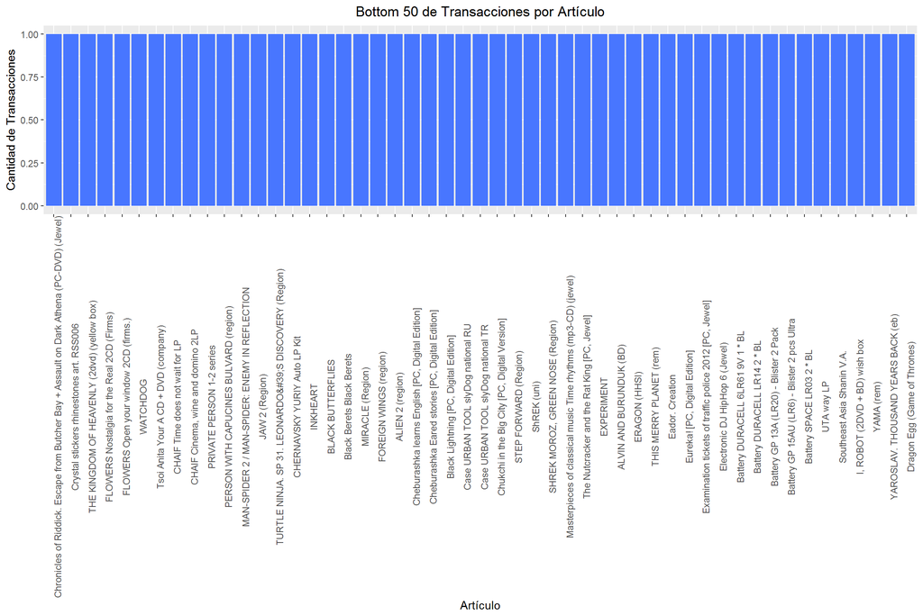

```r
aux_plot<-datos_train%>%
  group_by(item_id)%>%
  summarize(count_items=n(),
            item_name=unique(item_name))%>%
  arrange(desc(count_items))

aux_plot<-aux_plot[(nrow(aux_plot)-50):nrow(aux_plot),]%>%
  mutate(item_id=factor(item_id,aux_plot$item_id))

ggplot(aux_plot,aes(x = item_id, y = count_items))+
  geom_bar(stat = "identity",fill='royalblue1')+
  theme(axis.text.x=element_text(angle=90),
        plot.title = element_text(hjust=0.5))+
  ggtitle('Bottom 50 de Transacciones por Artículo')+
  xlab('Artículo')+
  ylab('Cantidad de Transacciones')+
  scale_x_discrete(labels=aux_plot$item_name)
```

```r
sum(aux_plot$count_items)/nrow(items)
```

```
## [1] 0.002300406
```

### 5.1.5 Categorías

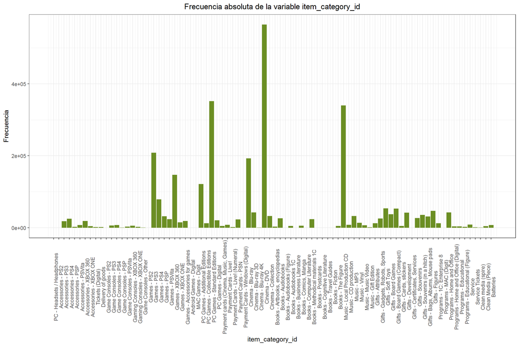

```r
GraficaFrecAbs(datos_train,"item_category_id",color='olivedrab',at=item_category$item_category_id,labs=item_category$item_category_name,angulo=90,bin.width=1)
```

Las categorías con mayor número de registros; es decir, con mayor número de transacciones son: Cinema-DVD, PC Games -Standard Editions, Music-Local Production CD, Games-PS3 y Cinema-Blu-Ray. Esto significa que las categorías con mayor número de transacciones en 1C son las relacionadas con el entretenimiento. Además representan alrededor del 56% de los registros. Las categorías con menor número de transacciones en el registro son Books - Fiction, Accessories - PS2, Books - Postcards, Game Consoles - PS2, Books - Cognitive Literature; es decir, categorías relacionadas con educación y PS2.

### 5.1.6 Item_price

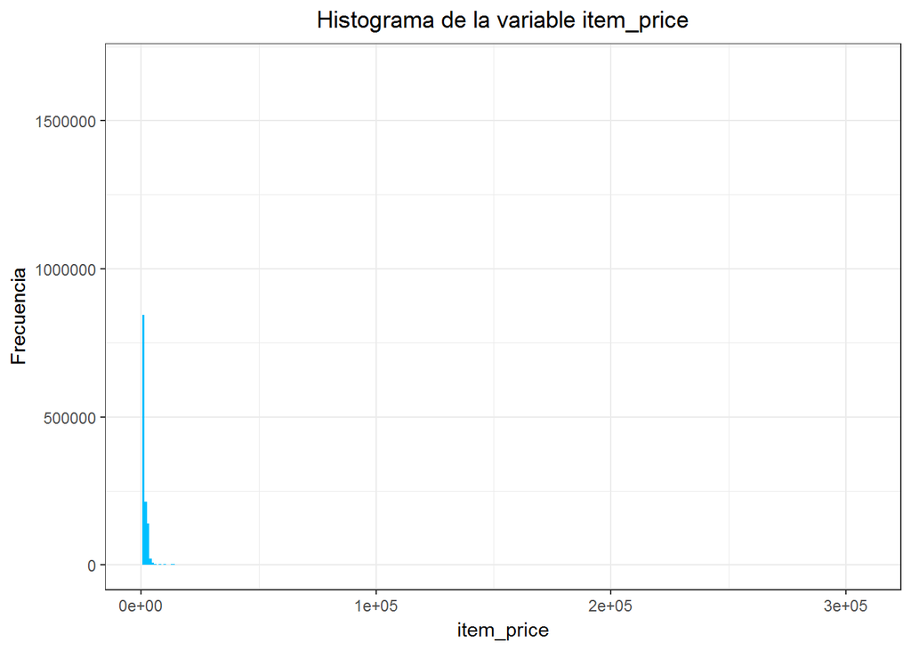

```r
GraficaHistograma(datos=datos_train,x='item_price',color='deepskyblue',bin.width=1000)
```

Se puede notar que la distribución del precio de los artículos está sesgada a la derecha y que existen varios datos atípicos. Calculemos deciles del precio y hagamos histogramas de cada decil.

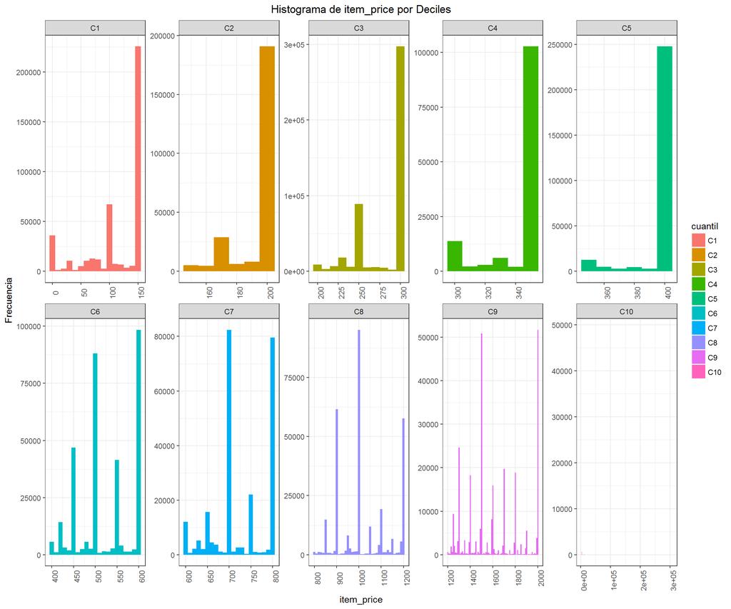

```r
# Asignamos los deciles a los que corresponde cada observación del precio.
cuantil_precio<-cut.at.n.tile(datos_train$item_price,n=10)

aux_plot<-datos_train%>%
  mutate(cuantil=as.factor(cuantil_precio))

ggplot(aux_plot,aes(item_price,fill=cuantil))+theme_bw()+
  geom_histogram(binwidth = 10) +
  facet_wrap(~cuantil,nrow=2,scales='free')+
  ggtitle('Histograma de item_price por Deciles')+
  xlab('item_price')+
  ylab('Frecuencia')+
  theme(plot.title=element_text(hjust=0.5),
        axis.text.x=element_text(angle=90))
```

```r
tabla_cuantiles<-aux_plot%>%
  group_by(cuantil)%>%
  summarise(transactions=n(),
            media=mean(item_price),
            mediana=median(item_price),
            moda=getmode(item_price),
            min=min(item_price),
            max=max(item_price),
            desv.est=sd(item_price))

datatable(tabla_cuantiles)
```

|  | cuantil | transactions | media | mediana | moda | min | max | desv.est |
| --- | --- | --- | --- | --- | --- | --- | --- | --- |
| 1 | C1 | 409953 | 113.61620143996 | 149 | 149 | -1 | 149 | 47.947008201688 |
| 2 | C2 | 243722 | 192.901708171093 | 199 | 199 | 149.03 | 199 | 12.570473004205 |
| 3 | C3 | 445947 | 280.696057603292 | 299 | 299 | 199.066666667 | 299 | 27.8111905440024 |
| 4 | C4 | 129644 | 341.455301732164 | 349 | 349 | 299.083333333 | 349 | 16.1584823803046 |
| 5 | C5 | 275845 | 395.280318357344 | 399 | 399 | 349.09 | 399 | 11.9386304925832 |
| 6 | C6 | 327940 | 523.637993238404 | 499.5 | 599 | 399.01 | 599 | 61.5652284026522 |
| 7 | C7 | 243086 | 726.091531201954 | 699 | 799 | 599.01 | 799 | 61.6869161577894 |
| 8 | C8 | 312746 | 1022.15331839713 | 999 | 999 | 799.06 | 1199 | 114.404997546189 |
| 9 | C9 | 280121 | 1620.99490044024 | 1590 | 1999 | 1199.06 | 1999 | 249.170298328261 |
| 10 | C10 | 266845 | 4202.31213094629 | 2799 | 2599 | 1999.16666667 | 307980 | 4323.76373090253 |

El mayor número de registros pertenecen a los deciles 3, 6 y 1; mientras que el menor número de registros pertenecen a los deciles 4, 7 y 2.

De los histogramas por decil y de la tabla anterior, se puede notar que los primeros 5 deciles tienen una distribución de precio del artículo sesgada a la izquierda, la moda y mediana son iguales y mayores a la media (sobre todo en el primer decil). En el primer decil, existe un precio negativo que deberá ser limpiado en la siguiente fase. Los deciles 6 a 9 parecen presentar distribuciones multimodales, ligeramente sesgadas a la izquierda para los deciles 6 y 7 y más centradas para los deciles 8 y 9. Además, en los deciles 6, 7 y 9 la media se encuentra entre la mediana y la moda; mientras que en el cuantil 8 la media es superior a ambas. Por último, el décimo cuantil en la gráfica parecería no tener observaciones, sin embargo, esto se debe a que existe una observación atípica con valor 307980 que sesga la distribución.

Evidentemente la media, la mediana y la moda crecen con el cuantil; sin embargo, la desviación estándar no. La menor variabilidad se observa en los deciles 5, 2 y 4 y la mayor en los deciles 8,9 y 10. Esto está en línea con la distribución del total de los precios presentada con anterioridad.

### 5.1.7 Item_cnt_day

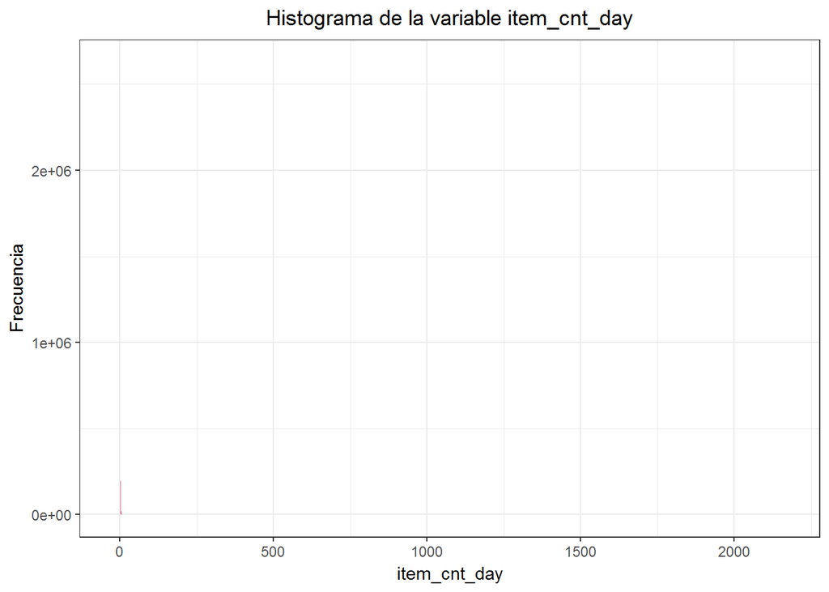

```r
GraficaHistograma(datos=datos_train,x='item_cnt_day',color='palevioletred',bin.width=1)
```

Evidentemente la distribución de **item_cnt_day** está sesgada a la derecha. Veamos mejor una tabla resumen de los datos.

```r
tabla_ItemCnt<-datos_train%>%
  group_by(item_cnt_day)%>%
  summarise(transactions=n())

datatable(tabla_ItemCnt)
```

|  | item_cnt_day | transactions |
| --- | --- | --- |
| 1 | -22 | 1 |
| 2 | -16 | 1 |
| 3 | -9 | 1 |
| 4 | -6 | 2 |
| 5 | -5 | 4 |
| 6 | -4 | 3 |
| 7 | -3 | 14 |
| 8 | -2 | 78 |
| 9 | -1 | 7252 |
| 10 | 1 | 2629372 |

[output cut: 188 more lines]

Ordenando por número de registros (columna transactions) para cada item_cnt_day, la razón de que la distribución esté sesgada es que existen 2,629,372 registros con una sola transacción. Es decir, la mayoría de las transacciones de 1C involucran la compra de un sólo artículo. Esto representa el 89% de los registros en la base de datos. Además, existen 194,201 registros con dos ventas, 47,350 registros con tres ventas, 19,685 registros con cuatros ventas y 10,474 registros con cinco ventas. Estos 5 valores de item_cnt_day representan el 98% de los registros de la muestra. De esta manera, las medidas de tendencia central están muy cercanas entre si.

En cuanto a las devoluciones, la mayoría de los registros de transacciones relacionados con una devolución involucran un sólo artículo. Llama la atención una devolución de 22 artículos iguales.

## 5.2 Análisis Bivariado

### 5.2.1 item_cnt_day vs item_price

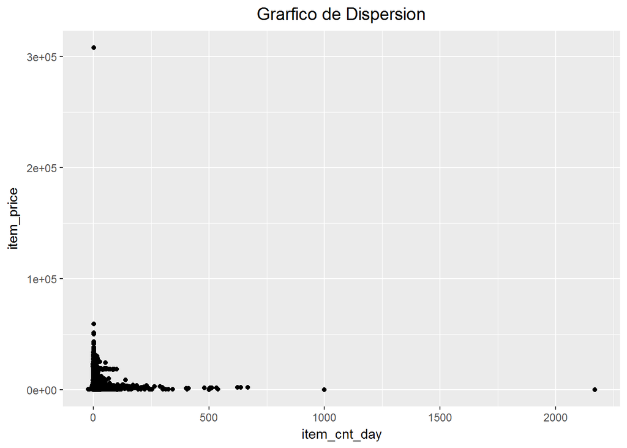

```r
GraficaBivar(datos_train,'item_cnt_day','item_price',ajuste='ninguno')
```

Se puede notar que el registro con mayor número de artículos vendidos es el de menor precio; mientras que el registro con menor número de artículos vendidos es el de mayor precio. Esto coincide con la intuición. No se puede apreciar una relación creciente/decreciente ni positiva/negativa entre estas dos variables.

### 5.2.2 item_cnt_day vs date_block_num

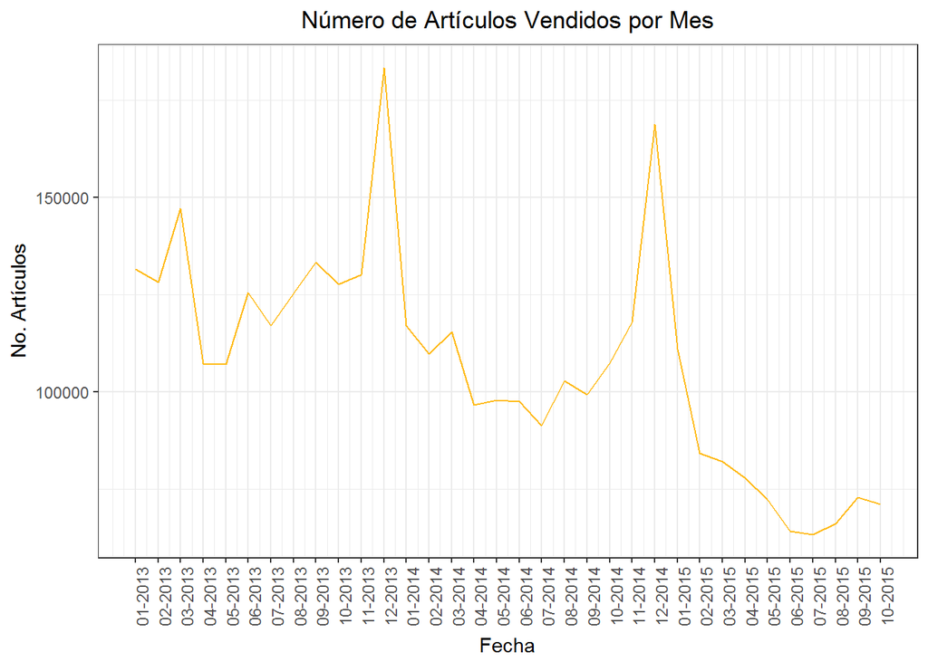

```r
aux_plot<-datos_train%>%
  group_by(date_block_num)%>%
  summarize(item_count_month=sum(item_cnt_day),
            mes=unique(substring(date,4,5)),
            anio=unique(substring(date,7)))%>%
  arrange(date_block_num)%>%
  mutate(Fecha=paste(mes,anio,sep='-'))


ggplot(aux_plot,aes(x = date_block_num, y = item_count_month))+theme_bw()+
  geom_line(color='darkgoldenrod1')+
  theme(axis.text.x=element_text(angle=90),
        plot.title = element_text(hjust=0.5))+
  ggtitle('Número de Artículos Vendidos por Mes')+
  xlab('Fecha')+
  ylab('No. Artículos')+
  scale_x_continuous(breaks=aux_plot$date_block_num,labels=aux_plot$Fecha)
```

Esta gráfica es muy parecida al número de registros por mes de la sección univariada; esto se debe a que, en su mayoría, los registros tienen una transacción de un sólo artículo.

### 5.2.3 item_price vs date_block_num

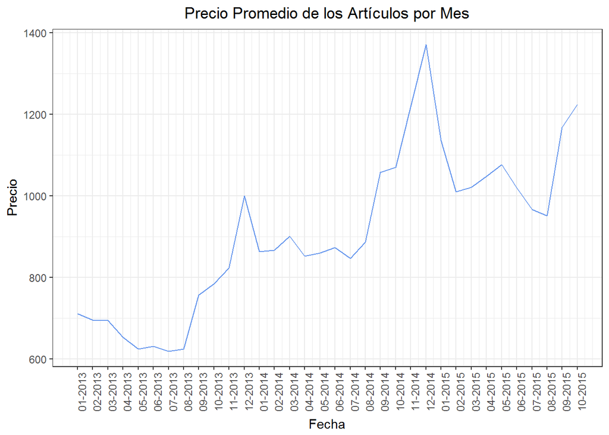

```r
aux_plot<-datos_train%>%
  group_by(date_block_num)%>%
  summarize(item_price_month=mean(item_price),
            mes=unique(substring(date,4,5)),
            anio=unique(substring(date,7)))%>%
  arrange(date_block_num)%>%
  mutate(Fecha=paste(mes,anio,sep='-'))


ggplot(aux_plot,aes(x = date_block_num, y = item_price_month))+theme_bw()+
  geom_line(color='cornflowerblue')+
  theme(axis.text.x=element_text(angle=90),
        plot.title = element_text(hjust=0.5))+
  ggtitle('Precio Promedio de los Artículos por Mes')+
  xlab('Fecha')+
  ylab('Precio')+
  scale_x_continuous(breaks=aux_plot$date_block_num,labels=aux_plot$Fecha)
```

### 5.2.4 item_cnt_day vs shop_id

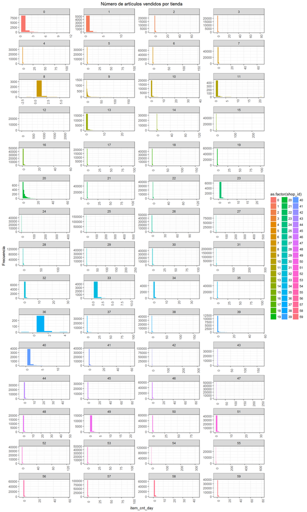

```r
ggplot(datos_train,aes(item_cnt_day,fill=as.factor(shop_id)))+theme_bw()+
  geom_histogram(binwidth = 1) +
  facet_wrap(~shop_id,nrow=15,scales='free')+
  ggtitle('Número de artículos vendidos por tienda')+
  xlab('item_cnt_day')+
  ylab('Frecuencia')+
  theme(plot.title=element_text(hjust=0.5),
        axis.text.x=element_text(angle=90))
```

### 5.2.5 item_price vs shop_id

```r
tabla_PrecioTienda<-datos_train%>%
  group_by(shop_id)%>%
  summarize(price_mean=mean(item_price,na.rm=TRUE),
            shop_name=unique(shop_name))%>%
  arrange(desc(price_mean))%>%
  select(shop_id,shop_name,price_mean)

datatable(tabla_PrecioTienda)
```

|  | shop_id | shop_name | price_mean |
| --- | --- | --- | --- |
| 1 | 12 | Online Emergency Store | 1464.3911421327 |
| 2 | 2 | Adygea shopping center &amp;quot;Mega&amp;quot; | 1350.638391441 |
| 3 | 34 | N.Novgorod SEC &amp;quot;RIO&amp;quot; | 1337.88202710971 |
| 4 | 20 | Moscow &amp;quot;Sale&amp;quot; | 1333.29571822304 |
| 5 | 9 | Outbound Trading | 1256.81224762307 |
| 6 | 18 | Krasnoyarsk shopping center &amp;quot;June&amp;quot; | 1174.52468849038 |
| 7 | 36 | Novosibirsk SEC &amp;quot;Gallery Novosibirsk&amp;quot; | 1166.07516339869 |
| 8 | 38 | Omsk shopping center &amp;quot;Mega&amp;quot; | 1164.95885893236 |
| 9 | 49 | Tyumen SEC &amp;quot;Crystal&amp;quot; | 1157.05957502201 |
| 10 | 48 | Tomsk SEC &amp;quot;Emerald City&amp;quot; | 1124.29293897668 |

[output cut: 50 more lines]

Las tiendas que en promedio tienen los precios más caros son: Online Emergency Store, Adygea shopping center Mega, N. Novgorod SEC Rio, Moscow Sale y Outbound Trading. En dichas tiendas el precio promedio de los artículos está alrededor de 1330. Las tiendas con el promedio de precios más bajos son: Kazan TC Behetle, Tyumen TC Green Beach, Yakutsk Shopping Centern, Yakutsk Ordzhonikide y Digital warehouse 1C- Online. Probablemente esta diferencia en precios se deba a la zona en que se encuentra la tienda (o si es online) y a la rama de productos de 1C que se enfoque.

### 5.2.6 item_cnt_day vs item_category_id

```r
tabla_Ventas_Cat<-datos_train%>%
  group_by(item_category_id)%>%
  summarize(cnt_sales=sum(item_cnt_day),
            item_category_name=unique(item_category_name))%>%
  arrange(desc(cnt_sales))%>%
  select(item_category_id,item_category_name,cnt_sales)

datatable(tabla_Ventas_Cat)
```

|  | item_category_id | item_category_name | cnt_sales |
| --- | --- | --- | --- |
| 1 | 40 | Cinema - DVD | 634171 |
| 2 | 30 | PC Games - Standard Editions | 456540 |
| 3 | 55 | Music - Local Production CD | 348591 |
| 4 | 19 | Games - PS3 | 254887 |
| 5 | 37 | Cinema - Blu-ray | 203284 |
| 6 | 71 | Gifts - Bags, Albums, Mouse pads | 187998 |
| 7 | 28 | PC Games - Additional Editions | 174954 |
| 8 | 23 | Games - XBOX 360 | 169944 |
| 9 | 20 | Games - PS4 | 127319 |
| 10 | 65 | Gifts - Board Games (Compact) | 73077 |

[output cut: 74 more lines]

Las categorías con mayor número de unidades vendidas son las relacionadas con el entretenimiento (cine, música y videojuegos). En contraste, las categorías con menor número de unidades vendidas son las relacionadas con PS2, la educación y los audiolibros.

### 5.2.7 item_price vs item_category_id

```r
tabla_Precio_Cat<-datos_train%>%
  group_by(item_category_id)%>%
  summarize(price_mean=mean(item_price, na.rm=TRUE),
            item_category_name=unique(item_category_name))%>%
  arrange(desc(price_mean))%>%
  select(item_category_id,item_category_name,price_mean)

datatable(tabla_Precio_Cat)
```

|  | item_category_id | item_category_name | price_mean |
| --- | --- | --- | --- |
| 1 | 12 | Game Consoles - PS4 | 22889.2991083707 |
| 2 | 16 | Gaming Consoles - XBOX ONE | 18682.5610046879 |
| 3 | 11 | Game Consoles - PS3 | 12686.742017788 |
| 4 | 15 | Gaming Consoles - XBOX 360 | 12024.5646133173 |
| 5 | 14 | Game Consoles - PSVita | 9263.11442333558 |
| 6 | 13 | Game Consoles - PSP | 4572.15709859155 |
| 7 | 74 | Programs - MAC (Digit) | 3403.57142857143 |
| 8 | 60 | Music - Gift Edition | 3319.48750819672 |
| 9 | 20 | Games - PS4 | 2791.77982006119 |
| 10 | 7 | Accessories - XBOX ONE | 2713.552295342 |

[output cut: 74 more lines]

Los artículos con el menor precio promedio son principalmente videojuegos.

### 5.2.8 item_cnt_day vs item_id

Dado que se tienen 22170 posibles artículos, no se grafica la distribución del número de unidades vendidas de cada uno. En su lugar, se presentan tablas del top-50 y bottom-50 de artículos vendidos.

```r
tabla_Ventas_Art<-datos_train%>%
  group_by(item_id)%>%
  summarize(cnt_sales=sum(item_cnt_day),
            item_name=unique(item_name))%>%
  arrange(desc(cnt_sales))%>%
  select(item_id, item_name,cnt_sales)

datatable(tabla_Ventas_Art[1:50,])
```

|  | item_id | item_name | cnt_sales |
| --- | --- | --- | --- |
| 1 | 20949 | Corporate package undershirt 1C Interest white (34 * 42) 45 microns | 187642 |
| 2 | 2808 | Diablo III [PC, Jewel, Russian version] | 17245 |
| 3 | 3732 | Grand Theft Auto V [PS3, Russian subtitles] | 16642 |
| 4 | 17717 | Acceptance of funds for 1C-Online | 15830 |
| 5 | 5822 | Playstation Store wallet replenishment: Payment card 1000 rub. | 14515 |
| 6 | 3734 | Grand Theft Auto V [Xbox 360, Russian subtitles] | 11688 |
| 7 | 6675 | Sony PlayStation 4 (500 Gb) Black (CUH-1008A / 1108A / B01) | 10289 |
| 8 | 3731 | Grand Theft Auto V [PC, Russian subtitles] | 10099 |
| 9 | 1855 | Battlefield 4 [PC, Russian version] | 10032 |
| 10 | 16787 | One of us [PS3, Russian version] | 9227 |

[output cut: 40 more lines]

Muchos de los artículos más vendidos son del área de entretenimiento, en especial videojuegos.

```r
tabla_Ventas_Art<-tabla_Ventas_Art%>%
  arrange(cnt_sales)

datatable(tabla_Ventas_Art[1:50,])
```

|  | item_id | item_name | cnt_sales |
| --- | --- | --- | --- |
| 1 | 1590 | Assassin&amp;#39;s Creed 3. Freedom Edition [PC, Russian version] | -11 |
| 2 | 11871 | Snake | -1 |
| 3 | 13474 | Sony PS3 (320 Gb) Kit (CECH-2508B) + FIFA 12 Game | -1 |
| 4 | 18062 | Robopet Dog | -1 |
| 5 | 4591 | MCCARTNEY, PAUL In Red Square (Company) | 0 |
| 6 | 7547 | VideoStudio Pro X6 IE Windows Mini-Box | 0 |
| 7 | 8515 | English. 2 - 5 class (Jewel) | 0 |
| 8 | 13477 | Sony PS3 (320 Gb) Kit (CECH-3008B) &amp;quot;+ game&amp;quot; Wizard &amp;quot;+&amp;quot; PS Move Starter Pack &amp;quot; | 0 |
| 9 | 0 | ! IN POWER OF OVERVIEW (PLASTIC) D | 1 |
| 10 | 4 | *** THE BOX (GLASS) D | 1 |

[output cut: 40 more lines]

### 5.2.9 item_price vs item_id

Dado que se tienen 22170 posibles artículos, no se grafica la distribución del precio promedio de cada uno. En su lugar, se presentan tablas del top-50 y bottom-50 de artículos con base en su precio promedio.

```r
tabla_Precio_Art<-datos_train%>%
  group_by(item_id)%>%
  summarize(price_mean=mean(item_price, na.rm=TRUE),
            item_name=unique(item_name))%>%
  arrange(desc(price_mean))%>%
  select(item_id,item_name,price_mean)

datatable(tabla_Precio_Art[1:50,])
```

|  | item_id | item_name | price_mean |
| --- | --- | --- | --- |
| 1 | 6066 | Radmin 3 - 522 persons. | 307980 |
| 2 | 13199 | Collection Chess (Lord of the Rings) | 50999 |
| 3 | 7241 | UserGate Proxy &amp;amp; Firewall 6.X with the Entensys URL Filtering site filtering module for up to 200 sessions (Academic / Social) | 49782 |
| 4 | 7238 | UserGate Proxy &amp;amp; Firewall 6.X up to 100 sessions | 42000 |
| 5 | 14173 | License 1C-Bitrix: Site Management - Expert | 40900 |
| 6 | 13403 | Kit &amp;quot;Microsoft Xbox One 1TB Limited Edition Halo 5 +&amp;quot; Halo 5. Limited Edition &amp;quot;[KF6-00012] | 39990.5 |
| 7 | 5748 | Photoshop 13 Windows Russian BOX | 35132.8571428571 |
| 8 | 13503 | Sony PlayStation 4 (1Tb) Black (CUH-1208B) Kit + Assassin&amp;#39;s Creed: Syndicate + Watch_Dogs Game | 34990 |
| 9 | 13448 | Sony PlayStation 4 (1Tb) Black (CUH-1208B) + Uncharted game: Nathan Drake. Collection | 34823.3333333333 |
| 10 | 2410 | CorelDRAW Graphics Suite X6 - Small Business Edition Russian BOX | 34713.5 |

[output cut: 40 more lines]

Los artículos más caros son los relacionados con licencias de software empresarial y, al parecer, algunas consolas de videojuegos.

```r
tabla_Precio_Art<-tabla_Precio_Art%>%
  arrange(price_mean)

datatable(tabla_Precio_Art[1:50,])
```

|  | item_id | item_name | price_mean |
| --- | --- | --- | --- |
| 1 | 20949 | Corporate package undershirt 1C Interest white (34 * 42) 45 microns | 4.91485569700674 |
| 2 | 22098 | Battery SPACE LR03 2 * BL | 7 |
| 3 | 4275 | Krater Character DLC Mayhem MK13 [PC, Digital Edition] | 8.27272727272727 |
| 4 | 4881 | Monday Night Combat [PC, Digital Edition] | 10 |
| 5 | 13090 | Map of Zhukovsky | 11 |
| 6 | 11853 | Snake VALENTINE 16 cm | 12.5592736705576 |
| 7 | 13598 | Kraft package &amp;quot;Interesting gifts&amp;quot; -Orange | 13.0131129807692 |
| 8 | 11867 | Serpent cord 15 cm | 13.620847145488 |
| 9 | 22010 | The Nutcracker and the Rat King [PC, Jewel] | 14 |
| 10 | 7756 | Warhammer 40,000. Dawn of War II. Retribution. Set &amp;quot;Imperial Guard&amp;quot; [PC, Digital Edition] | 15 |

[output cut: 40 more lines]

Los artículos con el menor precio promedio son principalmente videojuegos.

### 5.2.10 shop_id vs item_id

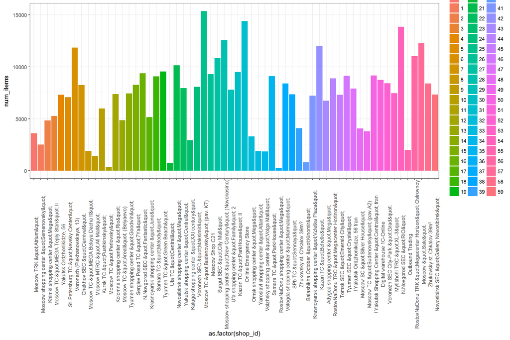

```r
tabla_TiendaArt<-datos_train%>%
  group_by(shop_id)%>%
  summarize(shop_name=unique(shop_name),
            num_items=length(unique(item_id)))%>%
  arrange(desc(num_items))

ggplot(tabla_TiendaArt, aes(x=as.factor(shop_id),y=num_items,fill=as.factor(shop_id)))+theme_bw()+
  geom_bar(stat='identity')+
  scale_x_discrete(labels=tabla_TiendaArt$shop_name)+
  theme(axis.text.x = element_text(angle=90))
```

Las tiendas con el mayor catálogo de artículos se ubican en su mayoría en Moscú y San Petersburgo; en contraste, las tiendas con el menor catálogo de artículos están en ciudades pequeñas.

## 5.3 Multivariado

Dado que el objetivo del proyecto será el predecir las ventas mensuales por artículo por tienda, el análisis multivariado se enfoca en analizar la relación entre las variables *shop_id*,*item_id*,*item_cnt_day* e *item_price* a lo largo de los meses en la muestra.

### 5.3.1 Serie de tiempo de la cantidad vendida por tienda

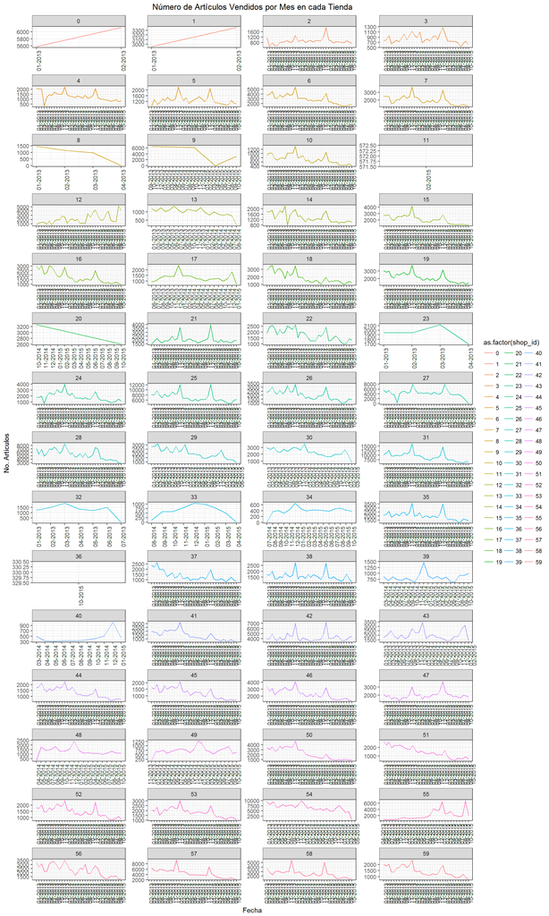

```r
aux_plot<-datos_train%>%
  group_by(date_block_num,shop_id)%>%
  summarize(item_count_month=sum(item_cnt_day),
            mes=unique(substring(date,4,5)),
            anio=unique(substring(date,7)))%>%
  arrange(shop_id,date_block_num)%>%
  mutate(Fecha=paste(mes,anio,sep='-'))


ggplot(aux_plot,aes(x = date_block_num, y = item_count_month,color=as.factor(shop_id)))+theme_bw()+
  geom_line()+
  facet_wrap(~as.factor(shop_id),nrow=15,scales='free')+
  theme(axis.text.x=element_text(angle=90),
        plot.title = element_text(hjust=0.5))+
  ggtitle('Número de Artículos Vendidos por Mes en cada Tienda')+
  xlab('Fecha')+
  ylab('No. Artículos')+
  scale_x_continuous(breaks=aux_plot$date_block_num,labels=aux_plot$Fecha)
```

De la gráfica anterior se puede notar lo siguiente:

### 5.3.2 Serie de tiempo del precio promedio por tienda

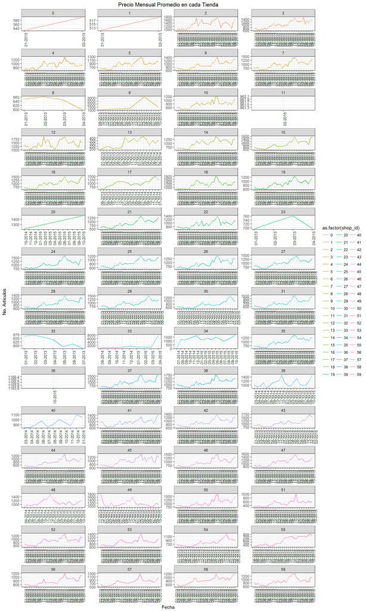

```r
aux_plot<-datos_train%>%
  group_by(date_block_num,shop_id)%>%
  summarize(price_mean=mean(item_price,na.rm=TRUE),
            mes=unique(substring(date,4,5)),
            anio=unique(substring(date,7)))%>%
  arrange(shop_id,date_block_num)%>%
  mutate(Fecha=paste(mes,anio,sep='-'))


ggplot(aux_plot,aes(x = date_block_num, y = price_mean,color=as.factor(shop_id)))+theme_bw()+
  geom_line()+
  facet_wrap(~as.factor(shop_id),nrow=15,scales='free')+
  theme(axis.text.x=element_text(angle=90),
        plot.title = element_text(hjust=0.5))+
  ggtitle('Precio Mensual Promedio en cada Tienda')+
  xlab('Fecha')+
  ylab('No. Artículos')+
  scale_x_continuous(breaks=aux_plot$date_block_num,labels=aux_plot$Fecha)
```

De la gráfica anterior se puede notar lo siguiente:

El precio promedio en cada tienda es de tendencia creciente en la mayoría de los casos. Existen algunas tiendas con pocas observaciones y/o con series de tiempo incompletas; esto se debe a que hay tiendas que tienen un sólo registro y por lo tanto no es posible graficar una línea.

### 5.3.3 Serie de tiempo de la cantidad mensual vendida por categoría

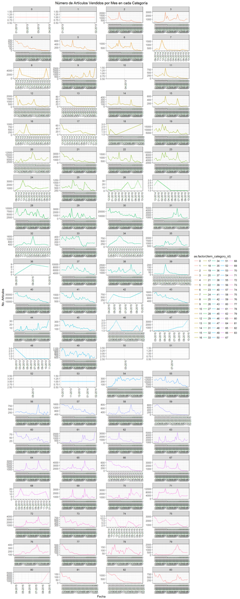

```r
aux_plot<-datos_train%>%
  group_by(date_block_num,item_category_id)%>%
  summarize(item_count_month=sum(item_cnt_day),
            mes=unique(substring(date,4,5)),
            anio=unique(substring(date,7)))%>%
  arrange(item_category_id,date_block_num)%>%
  mutate(Fecha=paste(mes,anio,sep='-'))


ggplot(aux_plot,aes(x = date_block_num, y = item_count_month,color=as.factor(item_category_id)))+theme_bw()+
  geom_line()+
  facet_wrap(~as.factor(item_category_id),nrow=21,scales='free')+
  theme(axis.text.x=element_text(angle=90),
        plot.title = element_text(hjust=0.5))+
  ggtitle('Número de Artículos Vendidos por Mes en cada Categoría')+
  xlab('Fecha')+
  ylab('No. Artículos')+
  scale_x_continuous(breaks=aux_plot$date_block_num,labels=aux_plot$Fecha)
```

Las series de tiempo del número de artículos vendidos cada mes por categoría del artículo son muy variables. Hay tiendas que tienen una tendencia decreciente a lo largo de la muestra, otras que tienen una tendencia creciente y unas cuantas que se mantienen estables. Esto debe estar relacionado con dos cosas: que el inventario en cada momento de tiempo varía y que algunos artículos se ponen “de moda” mientras que otros van en desuso. Es común observar picos en los últimos meses de cada año. Nuevamente se tiene el problema de series de tiempo incompletas para algunas categorías.

[figure not shown]

```r
aux_plot<-datos_train%>%
  group_by(date_block_num,item_category_id)%>%
  summarize(item_count_month=sum(item_cnt_day),
            mes=unique(substring(date,4,5)),
            anio=unique(substring(date,7)))%>%
  arrange(item_category_id,date_block_num)%>%
  mutate(Fecha=paste(mes,anio,sep='-'))


ggplot(aux_plot,aes(x = date_block_num, y = item_count_month,color=as.factor(item_category_id)))+theme_bw()+
  geom_line()+
  facet_wrap(~as.factor(item_category_id),nrow=21,scales='free')+
  theme(axis.text.x=element_text(angle=90),
        plot.title = element_text(hjust=0.5))+
  ggtitle('Precio Mensual Promedio en Cada Categoría')+
  xlab('Fecha')+
  ylab('No. Artículos')+
  scale_x_continuous(breaks=aux_plot$date_block_num,labels=aux_plot$Fecha)
```